# Soccer/Football Match outcome Prediction

## Question: Which in-game performance metrics best predict the outcome of a soccer/football match?

## Purpose: This project uses match and team statistics from the 2024-2025 season across 400+ leagues worldwide to build a machine learning classification model that predicts wether a team wins, draws, or loses based on thier in-game performance. The goal is to identify which tactical and statistical factors are the most effective at predicting match outcomes.

## Dataset ESPN Soccer Data via Kaggle - includes 30,000+ Match fixtures and team-level statistics across the 24/25 season.

## Approach:

1. Data loading / merging
2. Data cleaning
3. Exploratory Data Analysis
4. Feature Engineering
5. Machine learning modeling and evaluation

## Importing Data

Data loaded from the ESPN Soccer dataset. fixtures.csv: contains match results and team IDs teamStats.csv contains per-match performance statistics for each team teams.csv and leagues.csv provide reference information for filtering and joining later in the analysis.

```python
import pandas as pd

fixtures = pd.read_csv("base_data/fixtures.csv")
team_stats = pd.read_csv("base_data/teamStats.csv")
teams = pd.read_csv("base_data/teams.csv")
leagues = pd.read_csv("base_data/leagues.csv")

print(fixtures.head(),
        fixtures.shape,
        fixtures.dtypes,
        fixtures.columns.tolist()
)
```

```
   Rn  seasonType  leagueId  eventId                 date  venueId  \
0   1       12136      3922   689519  2024-01-01 05:00:00     8680
1   2       12136      3922   694555  2024-01-01 13:30:00     4775
2   3       12136      3922   693431  2024-01-02 13:00:00     7614
3   4       12136      3922   694586  2024-01-04 12:00:00     9877
4   5       12136      3922   690701  2024-01-04 13:30:00     9876

   attendance  homeTeamId  awayTeamId  homeTeamWinner  awayTeamWinner  \
0       61916         627        4396            True           False
1           0         658        1928           False            True
2           0        4895        2621           False            True
3           0        1928        6723           False            True
4           0         655        4388            True           False

   homeTeamScore  awayTeamScore  homeTeamShootoutScore  awayTeamShootoutScore  \
0              5              0                      0                      0
1              1              2                      0                      0
2              0              4                      0                      0
3              1              2                      0                      0
4              1              0                      0                      0

   statusId           updateTime
0        28  2024-01-07 03:20:23
1        28  2024-01-07 03:20:24
2        28  2024-01-07 03:20:59
3        28  2024-01-07 03:21:28
4        28  2024-01-07 03:21:29   (67353, 17) Rn                        int64
seasonType                int64
leagueId                  int64
eventId                   int64
date                     object
venueId                   int64
attendance                int64
homeTeamId                int64
awayTeamId                int64
homeTeamWinner             bool
awayTeamWinner             bool
homeTeamScore             int64
awayTeamScore             int64
homeTeamShootoutScore     int64
awayTeamShootoutScore     int64
statusId                  int64
updateTime               object
dtype: object ['Rn', 'seasonType', 'leagueId', 'eventId', 'date', 'venueId', 'attendance', 'homeTeamId', 'awayTeamId', 'homeTeamWinner', 'awayTeamWinner', 'homeTeamScore', 'awayTeamScore', 'homeTeamShootoutScore', 'awayTeamShootoutScore', 'statusId', 'updateTime']
```

```python
print(team_stats.shape)
print(team_stats.head())
print(team_stats.isnull().sum())
```

```
(103849, 33)
   seasonType  eventId  teamId  teamOrder  possessionPct  foulsCommitted  \
0       12136   688265    4381          0           41.5             6.0
1       12136   688265     628          1           58.5            19.0
2       12136   689519     627          0           58.9             7.0
3       12136   689519    4396          1           41.1             6.0
4       12136   689956     448          0           52.9            11.0

   yellowCards  redCards  offsides  wonCorners  ...  accurateLongBalls  \
0          1.0       0.0       1.0         1.0  ...               24.0
1          1.0       0.0       3.0         3.0  ...               26.0
2          0.0       0.0       1.0        13.0  ...               27.0
3          2.0       0.0       1.0         3.0  ...               19.0
4          1.0       0.0       2.0         7.0  ...               20.0

   longballPct  blockedShots  effectiveTackles  totalTackles  tacklePct  \
0          0.4           0.0              12.0          21.0        0.6
1          0.6           1.0               7.0           9.0        0.8
2          0.6          10.0               9.0          16.0        0.6
3          0.3           3.0              12.0          16.0        0.8
4          0.8           4.0              10.0          14.0        0.7

   interceptions  effectiveClearance  totalClearance           updateTime
0           14.0                14.0            14.0  2024-01-10 21:36:53
1           14.0                 5.0             5.0  2024-01-10 21:36:53
2           22.0                10.0            10.0  2024-01-07 03:20:23
3           12.0                37.0            37.0  2024-01-07 03:20:23
4            7.0                 7.0             7.0  2024-03-25 02:42:41

[5 rows x 33 columns]
seasonType                0
eventId                   0
teamId                    0
teamOrder                 0
possessionPct         46733
foulsCommitted        46733
yellowCards           46733
redCards              46733
offsides              46733
wonCorners            46733
```

[output cut: 9 more lines]

```
accurateCrosses       46733
totalCrosses          46733
crossPct              46733
totalLongBalls        46733
accurateLongBalls     46733
longballPct           46733
blockedShots          46733
effectiveTackles      46733
totalTackles          46733
tacklePct             46733
interceptions         46733
effectiveClearance    46733
totalClearance        46733
updateTime                0
dtype: int64
```

## Dataset Merge & Target Feature Engineering

I merged the team performance stats (teamStats.csv) with the match results (fixtures.csv) on eventId as thats the relational key. teamStats has two rows per match (one per team), so I created a 'result' column that label each teams row from thier perspective. This is the varaible our model will try to predict.

```python
# Merge the datasets (Fixtures and Team Stats) to get match outcomes
df = pd.merge(fixtures[['eventId', 'homeTeamId', 'awayTeamId', 'homeTeamWinner', 'awayTeamWinner']], team_stats, on=['eventId'], how='left')
print(df.head())

# teamStats doesnt have who won the match, so label each row as win/draw/loss for the home team
def label_match_outcome(row):
    if row['teamId'] == row['homeTeamId']: # Checks if the team is home
        if row['homeTeamWinner'] == True:
               return 'Win' #If the home team won, label as 'Win'
        elif row['awayTeamWinner'] == True:
             return 'Loss' # If the away team won, label as 'Loss'
        else:
             return 'Draw'
    else:
        if row['awayTeamWinner'] == True: # Then the team is away
            return 'Win' # If the away team won, label as 'Win'
        elif row['homeTeamWinner'] == True:
            return 'Loss' # If the home team won, label as 'Loss'
        else:
             return 'Draw'

df['result'] = df.apply(label_match_outcome, axis=1)

print(df['result'].value_counts())
print(df.shape)
```

```
   eventId  homeTeamId  awayTeamId  homeTeamWinner  awayTeamWinner  \
0   689519         627        4396            True           False
1   689519         627        4396            True           False
2   694555         658        1928           False            True
3   694555         658        1928           False            True
4   693431        4895        2621           False            True

   seasonType  teamId  teamOrder  possessionPct  foulsCommitted  ...  \
0     12136.0   627.0        0.0           58.9             7.0  ...
1     12136.0  4396.0        1.0           41.1             6.0  ...
2     12136.0   658.0        0.0            NaN             NaN  ...
3     12136.0  1928.0        1.0            NaN             NaN  ...
4     12136.0  4895.0        0.0            NaN             NaN  ...

   accurateLongBalls  longballPct  blockedShots  effectiveTackles  \
0               27.0          0.6          10.0               9.0
1               19.0          0.3           3.0              12.0
2                NaN          NaN           NaN               NaN
3                NaN          NaN           NaN               NaN
4                NaN          NaN           NaN               NaN

   totalTackles  tacklePct  interceptions  effectiveClearance  totalClearance  \
0          16.0        0.6           22.0                10.0            10.0
1          16.0        0.8           12.0                37.0            37.0
2           NaN        NaN            NaN                 NaN             NaN
3           NaN        NaN            NaN                 NaN             NaN
4           NaN        NaN            NaN                 NaN             NaN

            updateTime
0  2024-01-07 03:20:23
1  2024-01-07 03:20:23
2  2024-01-07 03:20:24
3  2024-01-07 03:20:24
4  2024-01-07 03:20:59

[5 rows x 37 columns]
result
Loss    43035
Win     41582
Draw    35345
Name: count, dtype: int64
(119962, 38)
```

## Data Cleaning

After merging and adding the result column, rows with missing data were removed. Removing the missing rows ensured that no unusable data was left in important statistical columns of interest.

Dataframed Cleaned: 57,116 rows

```python
# Get rid of NaN rows in the merged dataset
df_clean = df.dropna(subset=['possessionPct', 'totalShots', 'shotsOnTarget',
                              'passPct', 'totalTackles', 'interceptions'])

print(df_clean.shape)
print(df_clean['result'].value_counts())
```

```
(57116, 38)
result
Loss    21921
Win     21918
Draw    13277
Name: count, dtype: int64
```

```python
# Check to see if the rows removed were all missing data or just some missing.
print(df[df[['possessionPct', 'totalShots', 'shotsOnTarget',
             'passPct', 'totalTackles', 'interceptions']].isnull().any(axis=1)].shape)

print(df[df[['possessionPct', 'totalShots', 'shotsOnTarget',
             'passPct', 'totalTackles', 'interceptions']].isnull().all(axis=1)].shape, 'all entries missing')
```

```
(62846, 38)
(62846, 38) all entries missing
```

```python
# Remove possesion = 0 and 100 not logically possible and likely data entry error
df_clean = df_clean[(df_clean['possessionPct'] > 0) & (df_clean['possessionPct'] < 100)]
```

## Exploratory Data Visualizations

The distribution plot shows a balanced spread of wins and losses, with draws being less frequent. The scatter plot of possession vs shots on target reveals a clear trend that teams with more shots on target are more likely to win. However, possession alone does not show a clear relationship with match result, suggesting a team can have low possession and still get a result.

This is a well-known reality in the sport, as teams set out tactically to have more or less of the ball depending on their style of play. In professional analytics, this is captured through Expected Goals (xG) — a metric that represents how dangerous an opportunity was, accounting for shot location, body angle, and other factors. Since event-level data required for xG is beyond the scope of this dataset, proxy variables will be engineered to capture a team's attacking lethality.

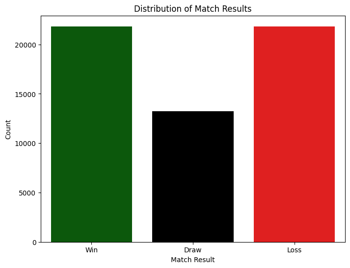

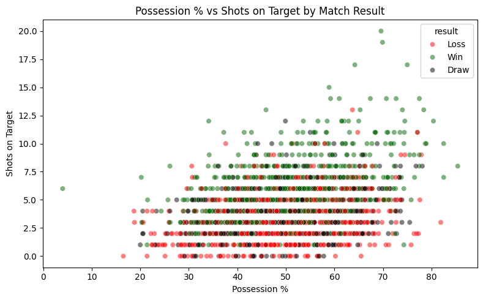

```python
# EDA exploration following cleaning
import matplotlib.pyplot as plt
import seaborn as sns

# Plot 1: Distribution of match outcomes/Results
plt.figure(figsize=(8, 6))
sns.countplot(x='result', data=df_clean, order=['Win', 'Draw', 'Loss'],
              palette={'Win': 'darkgreen', 'Draw': 'black', 'Loss': 'red'})
plt.title('Distribution of Match Results')
plt.xlabel('Match Result')
plt.ylabel('Count')
plt.show()

# Plot 2: Possesion and Shots on Target by Match Outcome
plt.figure(figsize=(8,5))
sns.scatterplot(data=df_clean.sample(2000, random_state=25),
                x='possessionPct',
                y='shotsOnTarget',
                hue='result',
                palette={'Win':'darkgreen', 'Draw':'black', 'Loss':'red'},
                alpha=0.5)
plt.title('Possession % vs Shots on Target by Match Result')
plt.xlabel('Possession %')
plt.ylabel('Shots on Target')
plt.tight_layout()
plt.show()
```

## Pearson Correlation

No single variable in the dataframe shows a strong correlation with the match result. shotsOnTarget has a moderate (.40) relationship, but nothing strong. This suggests that the sport has no real factors that can guarantee a result, as a statistically low-performing team in a given game can still come out with the win. Also, red cards and saves show negative correlations, which intuitively makes sense - a team playing with less players makes winning harder and a team facing more shots concedes more saves.

The results suggest that multiple variables together are required to predict better match results rather than relying on a single variable.

```python
# Encode result numerically so we can calculate correlation
# Win = 2, Draw = 1, Loss = 0
df_clean['result_encoded'] = df_clean['result'].map({'Win': 2, 'Draw': 1, 'Loss': 0})

# List of performance stats to analyze correlation with match result
feature_cols = ['possessionPct', 'foulsCommitted', 'yellowCards', 'redCards',
                'offsides', 'wonCorners', 'saves', 'totalShots', 'shotsOnTarget',
                'shotPct', 'passPct', 'accuratePasses', 'totalPasses',
                'crossPct', 'longballPct', 'blockedShots', 'effectiveTackles',
                'tacklePct', 'interceptions', 'effectiveClearance', 'result_encoded']

# Pearson Correlation of every stat against result
corr = df_clean[feature_cols].corr()[['result_encoded']].sort_values('result_encoded', ascending=False)
print(corr)
```

```
                    result_encoded
result_encoded            1.000000
shotsOnTarget             0.399969
shotPct                   0.290626
totalShots                0.227695
wonCorners                0.054919
crossPct                  0.052667
possessionPct             0.046815
effectiveClearance        0.035508
blockedShots              0.033692
accuratePasses            0.031849
foulsCommitted            0.029369
totalPasses               0.025134
longballPct               0.018637
offsides                  0.015827
effectiveTackles          0.010977
passPct                   0.007063
tacklePct                 0.005304
interceptions             0.004349
yellowCards              -0.018591
redCards                 -0.117055
saves                    -0.123813
```

## Feature Engineering

Three metrics were engineered to better capture a team's performance and provide deeper analysis into its relationship with a match result.

**Shot Efficiency**: The ratio of shots on target to total shots. This captures a team's clinical quality - essentially, a higher value indicates a more clinincal team - going beyond simple volume that could be generated from shots. Teams with 0 total shots receive a value of 0, reflecting a true data point possible in a game.

**Threat Per Possession**: This metric captures a team's attacking output relative to the time on the ball. The metric, in a way, accounts for differing styles of play. A counter-attacking team can have low possession but high threat if they're clinical when the ball is in their favor.

**Ball Recovery**: Sum of effective tackles and interceptions. A metric that represents a team's defensive activity, with higher values suggesting a more aggressive pressing team or defensive style.

Note: These features serve as proxies for attacking threat and defensive activity given the dataset at hand.

```python
# Feature Engineering

# Shot efficiency metric: how consistent do the shots hit the target
# A team with higher shot efficiency is more dangerous attacking-wise, which is a key factor in winning matches.
df_clean['shot_efficiency'] = df_clean['shotsOnTarget'] / df_clean['totalShots']

# Threat per possession: how much danger did you create relative to how much ball you had?
# Despite low possession, a team can still create a lot of danger if they are efficient with their attacking opportunities. This metric captures that dynamic.
df_clean['threat_per_possession'] = df_clean['shotsOnTarget'] / df_clean['possessionPct']

# Defensive metric: how well did you win the ball back?
# Combines tackles and interceptions into ball_recovery score
df_clean['ball_recovery'] = df_clean['effectiveTackles'] + df_clean['interceptions']

print(df_clean[['shot_efficiency', 'threat_per_possession', 'ball_recovery']].describe())
```

```
       shot_efficiency  threat_per_possession  ball_recovery
count     56856.000000           56906.000000   56906.000000
mean          0.352286               0.088403       9.508347
std           0.162187               0.050847      10.209890
min           0.000000               0.000000       0.000000
25%           0.250000               0.051903       0.000000
50%           0.333333               0.081967       8.000000
75%           0.454545               0.117647      18.000000
max           1.000000               1.500000      47.000000
```

```python
print((df_clean['totalShots'] == 0).sum())
print((df_clean['possessionPct'] == 0).sum())
```

```
50
0
```

```python
# Teams with 0 total shots get a shot efficiency of 0
# They created no danger - still a valid data point
df_clean['shot_efficiency'] = df_clean['shot_efficiency'].fillna(0)

# Confirm no more nulls in engineered features
print(df_clean.shape)
```

```
(56906, 42)
```

## Engineered Feature Analysis

The boxplots show that shot efficiency has the clearest separation across results. Winning teams consistently put a higher share of their shots on target compared to draws and losses, making it the strongest of the three engineered features.

Threat per possession is tightly distributed across all three results with little variation. It captures an interesting tactical dynamic but may not be a strong standalone predictor. The outliers visible are legitimate data points reflecting extreme counter attacking performances, not errors, so they were kept. Ball recovery distributions are almost identical across wins, draws and losses, suggesting that how much a team wins the ball back matters less than what they do with it once they have it. A key limitation here is that the metric does not account for where on the pitch the recovery happened. Winning the ball back in the final third is a completely different tactical statement than winning it in your own half, something that would require positional event level data to properly capture.

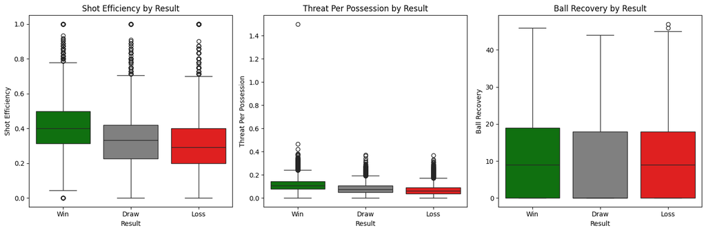

```python
# --- Engineered Features vs Match Result ---
# Do our proxy metrics actually separate wins from losses better than raw stats?

fig, axes = plt.subplots(1, 3, figsize=(15, 5))

# Shot Efficiency by Result
sns.boxplot(data=df_clean, x='result', y='shot_efficiency',
            order=['Win', 'Draw', 'Loss'],
            palette={'Win':'green', 'Draw':'gray', 'Loss':'red'},
            ax=axes[0])
axes[0].set_title('Shot Efficiency by Result')
axes[0].set_xlabel('Result')
axes[0].set_ylabel('Shot Efficiency')

# Threat Per Possession by Result
sns.boxplot(data=df_clean, x='result', y='threat_per_possession',
            order=['Win', 'Draw', 'Loss'],
            palette={'Win':'green', 'Draw':'gray', 'Loss':'red'},
            ax=axes[1])
axes[1].set_title('Threat Per Possession by Result')
axes[1].set_xlabel('Result')
axes[1].set_ylabel('Threat Per Possession')

# Ball Recovery by Result
sns.boxplot(data=df_clean, x='result', y='ball_recovery',
            order=['Win', 'Draw', 'Loss'],
            palette={'Win':'green', 'Draw':'gray', 'Loss':'red'},
            ax=axes[2])
axes[2].set_title('Ball Recovery by Result')
axes[2].set_xlabel('Result')
axes[2].set_ylabel('Ball Recovery')

plt.tight_layout()
plt.show()
```

```python
# Define our feature columns - everything except ID columns and target variables
features = ['possessionPct', 'foulsCommitted', 'yellowCards', 'redCards',
            'offsides', 'wonCorners', 'saves', 'totalShots', 'shotsOnTarget',
            'shotPct', 'passPct', 'totalPasses', 'accuratePasses',
            'crossPct', 'longballPct', 'blockedShots', 'effectiveTackles',
            'tacklePct', 'interceptions', 'effectiveClearance',
            'shot_efficiency', 'threat_per_possession', 'ball_recovery']

# Target variable - what we're predicting
X = df_clean[features]
y = df_clean['result']

print(X.shape)
print(y.value_counts())
```

```
(56906, 23)
result
Win     21835
Loss    21835
Draw    13236
Name: count, dtype: int64
```

```python
# Machine learning
from sklearn.model_selection import train_test_split
from sklearn.preprocessing import StandardScaler

# Data will be split into training and testing sets, with 20% of the data reserved for testing
X_train, X_test, y_train, y_test = train_test_split(X, y, test_size=0.2, random_state=25)

# Standardize features to have mean=0 and std=1 for better model performance
scaler = StandardScaler()


X_train_scaled = scaler.fit_transform(X_train)
X_test_scaled = scaler.transform(X_test)

print('Training set: ', X_train_scaled.shape)
print('Test set: ', X_test_scaled.shape)
```

[output not shown]

## Models

With the data being split into its appropriate training and testing sets, classification modeling was chosen as the most appropriate approach to identifying the relationship between performance metrics and results.

Models: **Logistic Regression**: Classification model that assumes a linear relationship between features and results. The model calculates the probability of each outcome and chooses the one with highest probability.

Both models are evaluated using accuracy and classification report - the models were trained on a 80/20 split of the data.

```python
from sklearn.linear_model import LogisticRegression
from sklearn.metrics import classification_report, confusion_matrix, accuracy_score

# Initialize and fit the logistic regression model
lr_mod = LogisticRegression(max_iter=1000, random_state=25)
# Train model on the scaled training data
lr_mod.fit(X_train_scaled, y_train)
# Predict on the test set
lr_pred = lr_mod.predict(X_test_scaled)

# Analyze model performance
print("Logistic Regression Classification Report:")
print(classification_report(y_test, lr_pred))
print()
print("Accuracy Score:", accuracy_score(y_test, lr_pred))
```

```
Logistic Regression Classification Report:
              precision    recall  f1-score   support

        Draw       0.24      0.01      0.02      2616
        Loss       0.53      0.73      0.61      4381
         Win       0.58      0.71      0.64      4385

    accuracy                           0.55     11382
   macro avg       0.45      0.48      0.42     11382
weighted avg       0.49      0.55      0.49     11382


Accuracy Score: 0.5541205412054121
```

```python
from sklearn.ensemble import RandomForestClassifier

# Initialize and fit the random forest model
rf_mod = RandomForestClassifier(n_estimators=100, random_state=25)

# Train model on the scaled training data
rf_mod.fit(X_train_scaled, y_train)
# Predict on the test set
rf_pred = rf_mod.predict(X_test_scaled)

# Analyze model performance
print("Random Forest Classification Report:")
print(classification_report(y_test, rf_pred))
print()
print("Accuracy Score:", accuracy_score(y_test, rf_pred))
```

```
Random Forest Classification Report:
              precision    recall  f1-score   support

        Draw       0.28      0.08      0.13      2616
        Loss       0.55      0.66      0.60      4381
         Win       0.57      0.69      0.63      4385

    accuracy                           0.54     11382
   macro avg       0.46      0.48      0.45     11382
weighted avg       0.49      0.54      0.50     11382


Accuracy Score: 0.5393603936039361
```

## Feature Importance

Ranking of which metrics the model relied on most when predicting the match result. A higher importance indicates that the model found that feature to be more useful across its decision trees.

The ranking of the metrics validates the engineering features, where two engineered proxy metrics ranked in the top 5 - threat per possession, which was the most important feature in the dataset, and shot efficiency ranked 5th. This confirms that capturing attacking lethality relative to possession and shot quality matters more to predicting outcomes than raw stats alone.

Possession percentage ranked second despite showing a weak Pearson correlation in EDA. This indicates that the model found it meaningful only when combined with other features rather than as a standalone predictor.

Fouls committed and won corners also ranked high, which logically makes sense. A team committing many fouls is often chasing the result or a team thats tactically disrupting the opponent's play, while winning corners reflects sustained dominant pressure on the opponent.

```
                  feature  importance
21  threat_per_possession    0.138601
0           possessionPct    0.100822
1          foulsCommitted    0.078425
5              wonCorners    0.066822
20        shot_efficiency    0.062706
6                   saves    0.056524
15           blockedShots    0.054902
7              totalShots    0.054086
2             yellowCards    0.051219
8           shotsOnTarget    0.045237
19     effectiveClearance    0.035725
12         accuratePasses    0.033523
11            totalPasses    0.033516
9                 shotPct    0.026337
22          ball_recovery    0.025750
16       effectiveTackles    0.024596
18          interceptions    0.024035
17              tacklePct    0.018225
4                offsides    0.017261
13               crossPct    0.016800
14            longballPct    0.015187
3                redCards    0.010446
10                passPct    0.009253
```

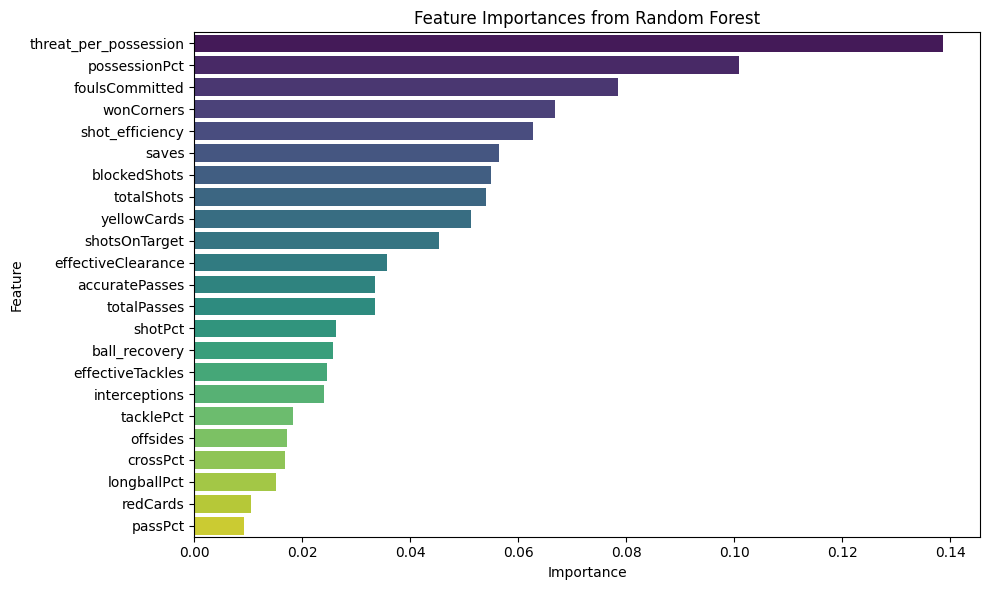

```python
import matplotlib.pyplot as plt
import numpy as np

feature_importances = pd.DataFrame({
    'feature': features,
    'importance': rf_mod.feature_importances_
}).sort_values(by='importance', ascending=False)
print(feature_importances)

# Plot
plt.figure(figsize=(10, 6))
sns.barplot(x='importance', y='feature', data=feature_importances, palette='viridis')
plt.title('Feature Importances from Random Forest')
plt.xlabel('Importance')
plt.ylabel('Feature')
plt.tight_layout()
plt.show()
```

```python
from sklearn.ensemble import GradientBoostingClassifier

# Gradient Boosting
gb_model = GradientBoostingClassifier(n_estimators=100,
                                       learning_rate=0.1,
                                       random_state=25)

gb_model.fit(X_train, y_train)

gb_preds = gb_model.predict(X_test)

# Evaluate
print("=== Gradient Boosting ===")
print(f"Accuracy: {accuracy_score(y_test, gb_preds):.4f}")
print()
print("Classification Report:")
print(classification_report(y_test, gb_preds))
```

```
=== Gradient Boosting ===
Accuracy: 0.5584

Classification Report:
              precision    recall  f1-score   support

        Draw       0.29      0.01      0.02      2616
        Loss       0.54      0.71      0.62      4381
         Win       0.58      0.73      0.65      4385

    accuracy                           0.56     11382
   macro avg       0.47      0.48      0.43     11382
weighted avg       0.50      0.56      0.49     11382
```

## Confusion Matrix

A confusion matrix shows where the model gets it right and where it gets confused. Rows represent what actually happened, columns represent what the model predicted.

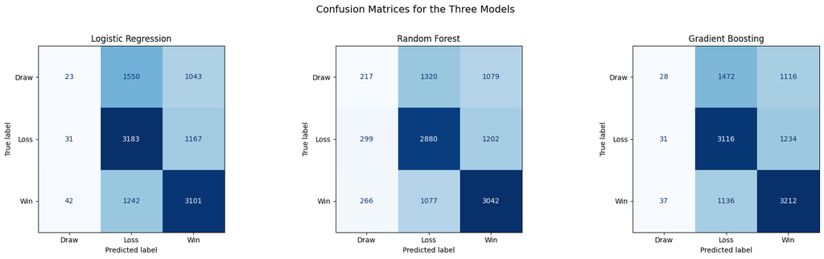

```python
from sklearn.metrics import ConfusionMatrixDisplay

# --- Confusion Matrix ---
fig, axes = plt.subplots(1, 3, figsize=(18, 5))

models = [
    ('Logistic Regression', lr_pred),
    ('Random Forest', rf_pred),
    ('Gradient Boosting', gb_preds)
]

for ax, (name, preds) in zip(axes, models):
    ConfusionMatrixDisplay.from_predictions(
        y_test, preds,
        display_labels=['Draw', 'Loss', 'Win'],
        colorbar=False,
        ax=ax,
        cmap='Blues'
    )
    ax.set_title(name)

plt.suptitle('Confusion Matrices for the Three Models', fontsize=14, y=1.02)
plt.tight_layout()
plt.show()
```

## Confusion Matrix Analysis

All three models tell the same story. The Draw row is consistently the weakest across every model — the diagonal for Draw is nearly empty, meaning the models almost never confidently predicted a draw, instead mistaking them for either a Win or a Loss.

Win and Loss predictions are reasonably strong with dark diagonals across all three models, showing the models can distinguish between winning and losing performances with moderate ability, however, they struggle at predicting draws.

## Model Evaluation

A third model, Gradient Boosting Classifier, was introduced — similar to Random Forest in using decision trees but adds the element of sequentially correcting each tree based on the errors of the last. It was added with the expectation that self correcting trees would improve prediction ability, however following its results all three models were nearly identical in performance.

Logistic Regression: 55% accuracy. Win F1 of 0.64, Loss F1 of 0.61, Draw F1 of 0.02. The model essentially gave up predicting draws.

Random Forest: 54% accuracy. Win F1 of 0.63, Loss F1 of 0.60, Draw F1 of 0.13. Slight improvement on draws while maintaining similar win and loss rates. Gradient Boosting: 56% accuracy. Win F1 of 0.65, Loss F1 of 0.62, Draw F1 of 0.02. Strongest overall but identical to Logistic Regression on draws.

# Conclusion

Three models of increasing complexity all resulted around 55% accuracy. This is not a modeling failure, however, it conveys a ceiling in predicting match outcomes from team stats alone. Soccer/football is a highly variant sport where factors like in game events, weather, and more complex metrics such as xG, possession in the final third, and pressing intensity are more appropriate predictors. Given the scope of this dataset and the absence of event level positional data, no model complexity was found to break through this ceiling.